# act_report

## Report: act_report

## Introduction

This is a report of Insights and Visualizations extracted from a popular twitter account We_Rate_Dog whereby the data is based rating random dogs out of 10. There can be also a short explanation of the dogs name, among other details concerned with a dog. The dataset was divided into 3 sets: twitter_archive_enhanced.csv,image_predictions.tsv and also a json.txt.

I had to follow the normal procedure of gathering, assessing and cleaning the data so that i can be able to derive insights and findings from it. I would later combine the above dataset to form a master dataframe called twitter_archive_master.csv. It is through the twitter_archive_master.csv dataframe that i have been able to perform my analysis. I have discussed my analyitical findings below:

## Exploratory Data Analysis

To explore my insights and visualizations,I employed EDA to analyze and investigate data sets and summarize their main characteristics. I have divided my EDA into two subsets.

- Insights
- Visualizations

### 1. Insights

###### From the master dataframe, I wanted to know if is there a likelihood of someone retweeting and liking a tweet at the same time.This is because from the Master dataframe the retweet_count and favorite_count had fewer margins of difference. This led to pose my first question below.

#### a) What is the Correlation between retweets and favorite 'liking' to see their relationship.

From my analysis, the correlation turned out to be 0.91294662741837018 which is a very strong positive correlation.

##### Conclusion

From the results i concluded that, an increase in retweet_count leads to increase in favorite_count. However this correlation does not imply causation.

###### Due to the fact that human being preferences differ from one another, I wanted to know which tweeting source was mostly used. Hence the question below:

#### b) Which tweeting Source is Popular?

From my analysis, I found that Most tweets were from Iphone users with 1955 users, followed by Twitter for Web with 28 users and lasts TweetDeck with 11 users.

##### Conclusion

From the above findings we can conclude that most people use twitter for Iphone as their source of tweeting.

###### Classifying a Dog based on its growth stage using a dog language (doggolingo) gave me the urge to explore which stage was the most common among the We_Rate-Dog Account. Hence the question.

#### c)Which Dog stage (Based on Doggolingo ) is the most Common.?

From my analysis the following were the findings. The common dog stage (doggolingo) is the pupper with 196 instances, followed by doggo 63 instances, puppo 22 instances, doggopupper 9 instances, floofer 7 instances meanwhile doggopuppo and doggofluffer both had 1 instance.

##### Conclusion

From the findings above we can confidently conclude that the common growth stage is the pupper and the least common being doggopuppo and doggofluffer.

### 2. Visualizations

I wanted to visually represent the last question from the insight inorder to see how they compare to each other: The question being:

- Which Dog stage (Based on Doggolingo ) is the most Common.?

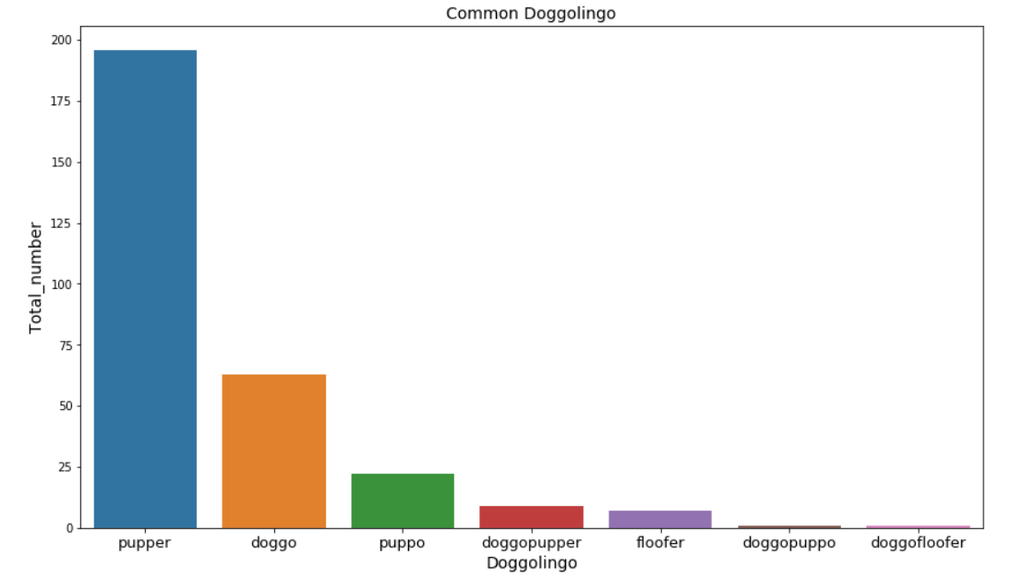

##### Conclusion

From the bar-graph above, we can visually ascertain that Pupper is the most common 'doggoligo' while doggopuppo and dogofloofer are the least common